# ENVS-193DS_spring-2025_final

Vikesh Dheeriya

2025-06-10

https://github.com/vikeshdh/ENVS-193DS_spring-2025_final/tree/main

Problem 1

1. In part 1, my coworker used a Spearman rank correlation, evidenced by Spearmens $\rho$ being greater than 0. This signifies that if nitrogen runoff and distance to headwaters were completely unrelated, we would only see the rho 3% of the time. In Part 2, they did a one-way ANOVA, comparing the mean nitrogen loads across five sources. The $/rho$ =0.02 tells me that the difference in means is significant.
2. The coworker could have listed the effect size. This would tell the reader how much of the variation is explained by the individual source, like if fertilizer had a greater effect size than grasslands, for example. One additional test they could have done is a linear mixed effects model where the source (urban deposition, fertilizer, etc) is the fixed effect and the site and year are the random intercepts. This tells us whether sources are explained by differences in site or differences in year, which isn’t accounted for in the ANOVA.
3. As distance from headwaters (km) increased, there is evidence to suggest that total nitrogen load (kg year^-1) also increased ($/rho$ = correlation coefficient, n = sample size, p = 0.03, $\alpha$ = signficance level). The average nitrogen load differed between the five source categories (urban land, atmospheric deposition, fertilizer, wastewater treatment, and grasslands) with one source of nitrogen contributing more than the others (one-way ANOVA, df = degrees of freedom, F = f-ratio, MSB = mean square, p = 0.02, $\alpha$ = 0.05)

```r
sst <- read.csv("data/SST_update2023.csv") # read in original file

sst_clean <- sst %>%                       # start with the raw data
  # Add explicit year & month columns
  mutate(
    year  = year(date),                    # extract year from a date column
    month = month(date, label = TRUE,      # extract month
                  abbr  = TRUE)
  ) %>%
  # Average within each year-month cell
  group_by(year, month) %>%
  summarise(mean_monthly_sst = mean(temp, na.rm = TRUE),
            .groups = "drop") %>%
  mutate(
    year  = factor(year),                  # keep years
    month = factor(month,
                   levels = month.abb,     # ensure Jan–Dec order
                   ordered = TRUE)
  )

 # look at random five-row subset
sst_clean %>%
  slice_sample(n = 5)
```

```
## # A tibble: 5 × 3
##   year  month mean_monthly_sst
##   <fct> <ord>            <dbl>
## 1 2001  Apr               12.1
## 2 1990  Apr               14.2
## 3 2011  Jun               14.1
## 4 1998  Aug               18.6
## 5 2007  Mar               13.0
```

```r
 # show data structure
str(sst_clean)
```

```
## tibble [504 × 3] (S3: tbl_df/tbl/data.frame)
##  $ year            : Factor w/ 42 levels "1982","1983",..: 1 1 1 1 1 1 1 1 1 1 ...
##  $ month           : Ord.factor w/ 12 levels "Jan"<"Feb"<"Mar"<..: 1 2 3 4 5 6 7 8 9 10 ...
##  $ mean_monthly_sst: num [1:504] 13.1 13.5 13.3 12.9 14.4 ...
```

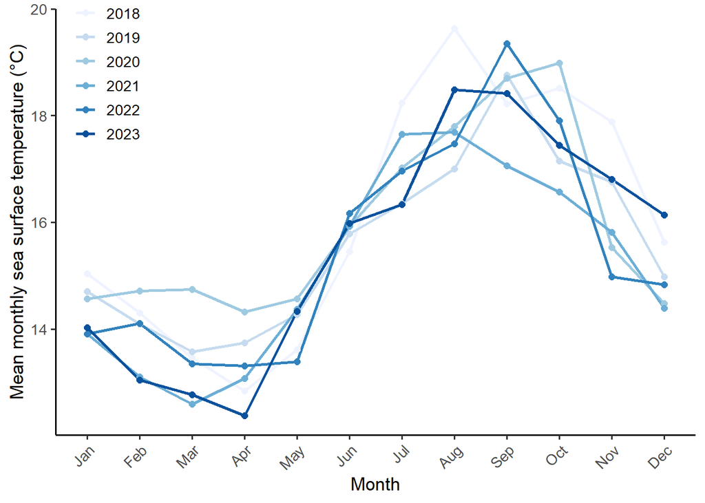

```r
sst_clean %>%
  filter(year %in% 2018:2023) %>% #filters from 2018 to 2023
  mutate(year = factor(year, levels = 2018:2023)) %>%
  ggplot(aes(month, mean_monthly_sst,
             group = year, colour = year)) +
  geom_line(size = 1) +
  geom_point(size = 2) +
  scale_colour_brewer(palette = "Blues", direction = 1, name = "Year") + #adds blue color scheme
  labs(x = "Month",
       y = "Mean monthly sea surface temperature (°C)") +
  theme_classic(base_size = 13) +
  theme(
    axis.text.x = element_text(angle = 45, vjust = 1, hjust = 1),
    legend.position   = c(0.08, 0.88),          # puts legend inside plot
    legend.background = element_rect(fill = "white", colour = NA),
    legend.key        = element_rect(fill = NA)
  )
```

Problem 3

1. The presence of a 1 means the target species occupied the nest box while the presence of a 0 indicates there is no species/ a different species that is occupying the nest box. The ‘e’ column 1 and 0’s indicate whether or not it is occupied, regardless of species type.
2. The main difference between Swift Parrots and Common Starlings and Tree martins are Swift Parrots are critically endangered due to deforestation and the introduction of a new predator while the Starlings and Martins are abundant, native species that exploit nest boxes intended for Swift Parrot species preservation.
3. The two summer breeding seasons of 2016 and 2019 represent the years where parrots were present at the site. Parrots were not present in between these years. The 2019 nesting boxes allowed the researchers to test a more effective management option, permanent boxes, compared to the 2016 breeding site.

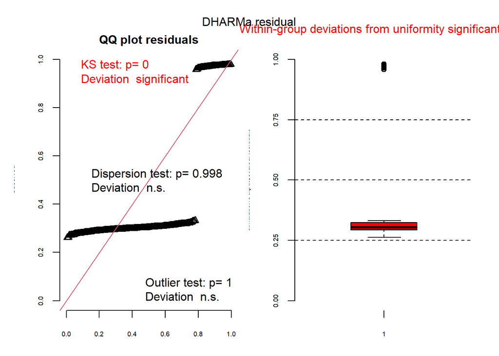

```r
nest_boxes <- read.csv("data/occdist.csv") |>
  clean_names() |>
  rename(distance_to_forest_edge = edge_distance) |> # descriptive variable name
  mutate(
    season = factor(season),                         # treat season as factor
    sp     = as.numeric(sp)                          # 0 / 1 occupancy
  )


# d) lookup table for the four candidate models
model_table <- tribble(
  ~model_number, ~season, ~distance_to_forest_edge, ~model_description,
  1,             "",      "",                       "Null model: no predictors",
  2,             "X",     "X",                      "Saturated model: all predictors",
  3,             "X",     "",                       "Season-only model",
  4,             "",      "X",                      "Distance-to-forest-edge-only model"
) # labels table with model names and number

#e) Generates linear models for each predictor

model1 <- lm(sp ~ 1, data = nest_boxes)  # null
model2 <- lm(sp ~ season + distance_to_forest_edge, data = nest_boxes)  # saturated
model3 <- lm(sp ~ season,data = nest_boxes)  # season only
model4 <- lm(sp ~ distance_to_forest_edge, data = nest_boxes)  # distance only

#f) Simulate residuals
model_1_res <- simulateResiduals(model1, n = 1000)
model_2_res <- simulateResiduals(model2, n = 1000)
model_3_res <- simulateResiduals(model3, n = 1000)
model_4_res <- simulateResiduals(model4, n = 1000)

# Save current graphics settings, then set up a 4×4 layout
old_par <- par(no.readonly = TRUE)           # store user’s defaults
par(mfrow = c(4, 4),                         # 4 rows × 4 columns
    mar   = c(3.2, 3.2, 1.5, 0.8),           # smaller margins
    cex   = 0.55, cex.axis = 0.55,           # shrink all text/symbols
    cex.lab = 0.55, cex.main = 0.55)

# f) Plot diagnostics

# Model 1
plot(model_1_res,
     main = "Model 1",
     testUniform = FALSE, testDispersion = FALSE,#removes unneccesary next from plot
     testOutliers = FALSE, quantreg = FALSE)
```

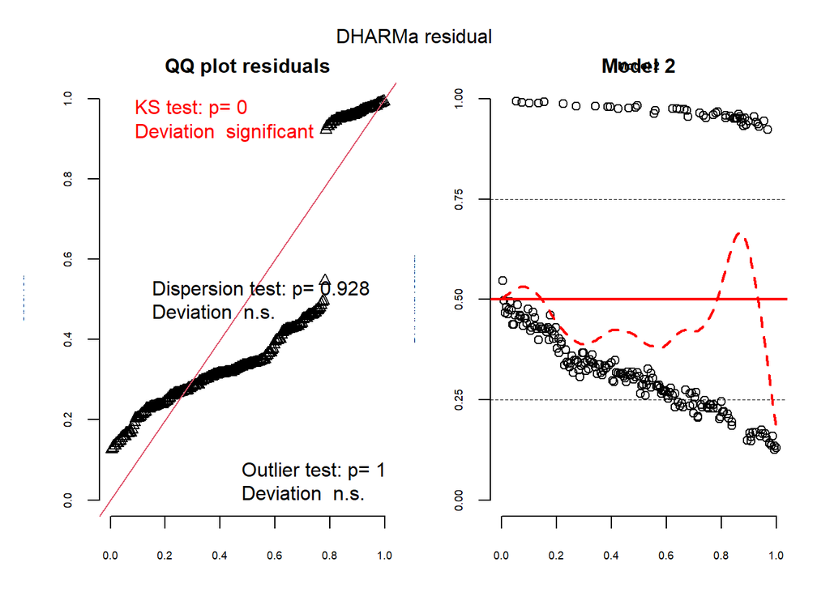

```r
# Model 2
plot(model_2_res,
     main = "Model 2",
     testUniform = FALSE, testDispersion = FALSE,
     testOutliers = FALSE, quantreg = FALSE)
```

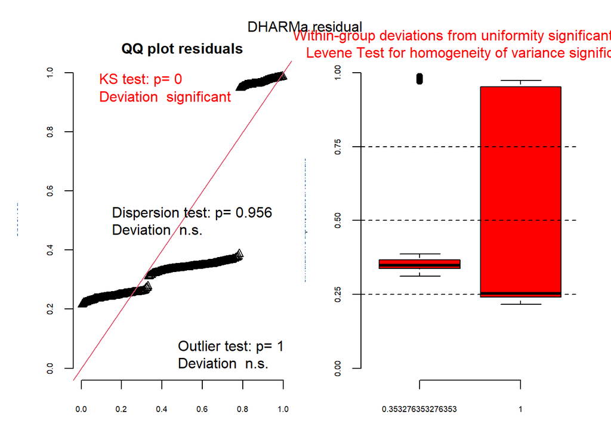

```r
# Model 3
plot(model_3_res,
     main = "Model 3",
     testUniform = FALSE, testDispersion = FALSE,
     testOutliers = FALSE, quantreg = FALSE)
```

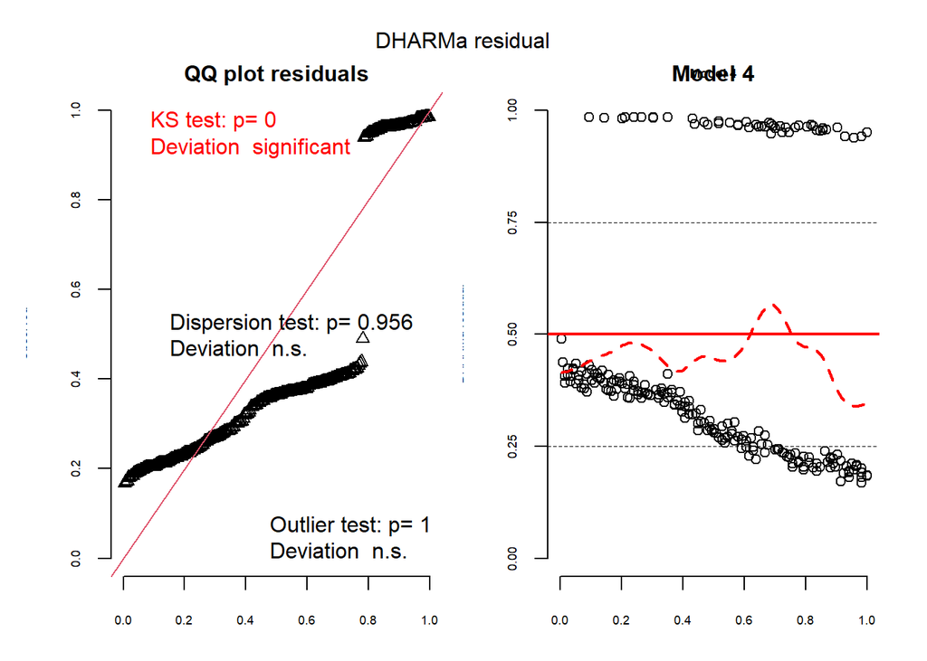

```r
# Model 4
plot(model_4_res,
     main = "Model 4",
     testUniform = FALSE, testDispersion = FALSE,
     testOutliers = FALSE, quantreg = FALSE)
```

```r
#  Restore original graphics settings
par(old_par)

#g) Selecting the best model

AICc(model1, model2, model3, model4) |> # performs AIC analysis on models
  arrange(AICc)
```

```
##        df     AICc
## model2  4 232.5485
## model4  3 235.9030
## model3  3 242.5425
## model1  2 245.0324
```

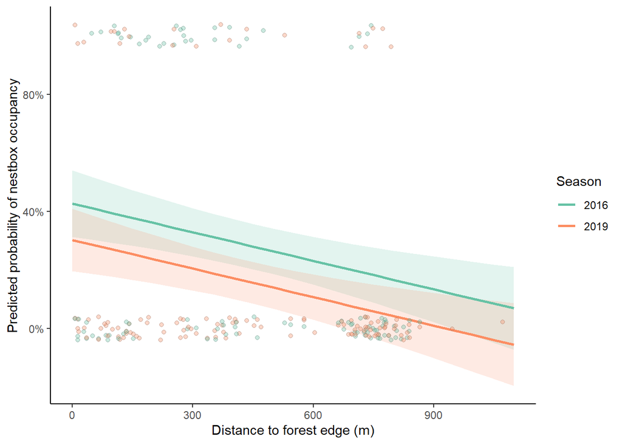

```r
#The best model, as determined by Akaike's Information Criterion is the model that predicts parrot occupance from both season and distance to forest edge. The high performance of this model indicates that combining season and proximity to forest edge is the best indicator of nest occupancy compared to combinations of other predictors.

#h) Visualizing model predictions

# 1. Predictions across the distance range, for every season (Model 2)
parrot_predictions <- ggpredict(
 model2,
  terms = c("distance_to_forest_edge",   # gives name to terms for ggpredict
            "season")                           # keep each season
) |>
  as_tibble() |>
  rename(
    distance_to_forest_edge = x,       # match raw data column
    season      = group,               # clearer name than "group"
    prob_hat    = predicted,           # keep column names identical in style
    lo95        = conf.low,
    hi95        = conf.high
  )

#h) Plot includes raw points model lines + 95 % CI shaded areas
ggplot(parrot_predictions, #lists axis names
       aes(x = distance_to_forest_edge,
           y = prob_hat,
           colour = season,
           fill   = season)) +
  # confidence band
  geom_ribbon(aes(ymin = lo95, ymax = hi95),
              alpha = 0.18, colour = NA) +
  # prediction line
  geom_line(size = 1) +
  # 0/1 occupancy data
  geom_jitter(data = nest_boxes,
              aes(y = sp),
              height = 0.04, width = 0,
              shape = 21, colour = "grey40", alpha = 0.35) +
  # non-default colours
  scale_colour_brewer(palette = "Set2", name = "Season") +
  scale_fill_brewer(palette = "Set2", guide  = "none") +
  #axis labels
  scale_y_continuous(labels = scales::percent_format(accuracy = 1)) +
  labs(x = "Distance to forest edge (m)",
       y = "Predicted probability of nestbox occupancy") +
  # minimal theme
  theme_classic(base_size = 11) +
  theme(panel.grid = element_blank())
```

Figure 1. Predicted Swift Parrot nest-box occupancy by distance to forest edge. Showing both 2016 and 2019 seasons, the lines show the linear model-predicted probability of nest box occupancy. The shaded areas are 95% confidence intervals. The points are reaw observations of occupancy where 0 = empty and 1 = occupied. Data: Stojanovic, Dejan et al. (2021). Do nest boxes breed the target species or its competitors? A case study of a critically endangered bird [Dataset]. Dryad. https://doi.org/10.5061/dryad.83bk3j9sb

```r
#j) Model Prediction Calculations

edge_preds <- ggpredict( # calcualates linear model predictions
model2,
  terms = c("distance_to_forest_edge [0,900]", "season") #sets edges to 0 and 900 meters from forest edge
) |>
  as_tibble() |> # creates basic table
  rename(
    distance_to_forest_edge = x,
    season      = group,
    prob_hat    = predicted,
    lo95        = conf.low,
    hi95        = conf.high
  )

edge_preds |> # creates deliverable table
  mutate(across(where(is.numeric), ~ round(.x, 3))) |>
  kable(
    caption = "Table 1. Predicted Swift Parrot nest box occupancy probabilities  at 0 m and 900 m from the forest edge for each season.",
    col.names = c("Distance to edge (m)",
                  "Season",
                  "Predicted p",
                  "Lower 95 % CI",
                  "Standard Error",
                  "Upper 95 % CI")
  )
```

Table 1. Predicted Swift Parrot nest box occupancy probabilities at 0 m and 900 m from the forest edge for each season.

[output not shown]

Problem 4

The visualizations are different from each other in the portrayal of soreness and color scheme. I didn’t initially think it was important to show soreness but I realized it adds another layer of emotion to the data. In both, I had a graph format with time on the x axis. I kept the linear format of jump vs time in both visualizations because I think its neccesary to tell a story. Evaluating trends over time is a crucial aspect of relatability for the reader as they see growth and decline. I got feedback on over complicating the visualization. I incorporated these changes by simplifying the color scheme to make it easier to understand quickly for the reader.